# Risk Factor Analysis

## Outcome Variable

**Outcome Variable:** haz

## Predictor Variables

**Intervention Variable:** earlybf

**Adjustment Set:**

- arm
- sex
- W_mage
- meducyrs
- feducyrs
- hhwealth_quart
- hfoodsec
- W_mhtcm
- vagbrth
- W_birthwt
- W_birthlen
- W_nrooms
- W_nchldlt5
- brthmon
- W_parity
- impfloor
- impsan
- safeh20
- delta_W_mage
- delta_meducyrs
- delta_feducyrs
- delta_hhwealth_quart
- delta_hfoodsec
- delta_W_mhtcm
- delta_vagbrth
- delta_W_birthwt
- delta_W_birthlen
- delta_W_nrooms
- delta_W_nchldlt5
- delta_brthmon
- delta_W_parity
- delta_impfloor
- delta_impsan
- delta_safeh20

## Stratifying Variables

The analysis was stratified on these variable(s):

- agecat
- studyid
- country

## Data Summary

| agecat | studyid | country | earlybf | n_cell | n |
| --- | --- | --- | --- | --- | --- |
| Birth | ki0047075b-MAL-ED | BANGLADESH | 1 | 159 | 256 |
| Birth | ki0047075b-MAL-ED | BANGLADESH | 0 | 97 | 256 |
| Birth | ki0047075b-MAL-ED | BRAZIL | 1 | 83 | 191 |
| Birth | ki0047075b-MAL-ED | BRAZIL | 0 | 108 | 191 |
| Birth | ki0047075b-MAL-ED | INDIA | 1 | 124 | 205 |
| Birth | ki0047075b-MAL-ED | INDIA | 0 | 81 | 205 |
| Birth | ki0047075b-MAL-ED | NEPAL | 1 | 79 | 173 |
| Birth | ki0047075b-MAL-ED | NEPAL | 0 | 94 | 173 |
| Birth | ki0047075b-MAL-ED | PERU | 1 | 214 | 287 |
| Birth | ki0047075b-MAL-ED | PERU | 0 | 73 | 287 |
| Birth | ki0047075b-MAL-ED | SOUTH AFRICA | 1 | 155 | 247 |
| Birth | ki0047075b-MAL-ED | SOUTH AFRICA | 0 | 92 | 247 |
| Birth | ki0047075b-MAL-ED | TANZANIA, UNITED REPUBLIC OF | 1 | 111 | 123 |
| Birth | ki0047075b-MAL-ED | TANZANIA, UNITED REPUBLIC OF | 0 | 12 | 123 |
| Birth | ki1000109-EE | PAKISTAN | 1 | 1 | 2 |
| Birth | ki1000109-EE | PAKISTAN | 0 | 1 | 2 |
| Birth | ki1000304b-SAS-CompFeed | INDIA | 1 | 14 | 177 |
| Birth | ki1000304b-SAS-CompFeed | INDIA | 0 | 163 | 177 |
| Birth | ki1017093c-NIH-Crypto | BANGLADESH | 1 | 23 | 27 |
| Birth | ki1017093c-NIH-Crypto | BANGLADESH | 0 | 4 | 27 |
| Birth | ki1126311-ZVITAMBO | ZIMBABWE | 1 | 6533 | 12319 |
| Birth | ki1126311-ZVITAMBO | ZIMBABWE | 0 | 5786 | 12319 |
| Birth | kiGH5241-JiVitA-3 | BANGLADESH | 1 | 212 | 19541 |
| Birth | kiGH5241-JiVitA-3 | BANGLADESH | 0 | 19329 | 19541 |
| Birth | kiGH5241-JiVitA-4 | BANGLADESH | 1 | 566 | 822 |
| Birth | kiGH5241-JiVitA-4 | BANGLADESH | 0 | 256 | 822 |
| 6 months | ki0047075b-MAL-ED | BANGLADESH | 1 | 147 | 240 |
| 6 months | ki0047075b-MAL-ED | BANGLADESH | 0 | 93 | 240 |
| 6 months | ki0047075b-MAL-ED | BRAZIL | 1 | 95 | 209 |
| 6 months | ki0047075b-MAL-ED | BRAZIL | 0 | 114 | 209 |
| 6 months | ki0047075b-MAL-ED | INDIA | 1 | 140 | 236 |
| 6 months | ki0047075b-MAL-ED | INDIA | 0 | 96 | 236 |
| 6 months | ki0047075b-MAL-ED | NEPAL | 1 | 96 | 236 |
| 6 months | ki0047075b-MAL-ED | NEPAL | 0 | 140 | 236 |
| 6 months | ki0047075b-MAL-ED | PERU | 1 | 202 | 273 |
| 6 months | ki0047075b-MAL-ED | PERU | 0 | 71 | 273 |
| 6 months | ki0047075b-MAL-ED | SOUTH AFRICA | 1 | 156 | 250 |
| 6 months | ki0047075b-MAL-ED | SOUTH AFRICA | 0 | 94 | 250 |
| 6 months | ki0047075b-MAL-ED | TANZANIA, UNITED REPUBLIC OF | 1 | 205 | 247 |
| 6 months | ki0047075b-MAL-ED | TANZANIA, UNITED REPUBLIC OF | 0 | 42 | 247 |
| 6 months | ki1000109-EE | PAKISTAN | 1 | 68 | 372 |
| 6 months | ki1000109-EE | PAKISTAN | 0 | 304 | 372 |
| 6 months | ki1000304b-SAS-CompFeed | INDIA | 1 | 98 | 1336 |
| 6 months | ki1000304b-SAS-CompFeed | INDIA | 0 | 1238 | 1336 |
| 6 months | ki1017093c-NIH-Crypto | BANGLADESH | 1 | 619 | 715 |
| 6 months | ki1017093c-NIH-Crypto | BANGLADESH | 0 | 96 | 715 |
| 6 months | ki1113344-GMS-Nepal | NEPAL | 1 | 151 | 510 |
| 6 months | ki1113344-GMS-Nepal | NEPAL | 0 | 359 | 510 |
| 6 months | ki1126311-ZVITAMBO | ZIMBABWE | 1 | 3968 | 7365 |
| 6 months | ki1126311-ZVITAMBO | ZIMBABWE | 0 | 3397 | 7365 |
| 6 months | kiGH5241-JiVitA-3 | BANGLADESH | 1 | 35 | 16811 |
| 6 months | kiGH5241-JiVitA-3 | BANGLADESH | 0 | 16776 | 16811 |
| 6 months | kiGH5241-JiVitA-4 | BANGLADESH | 1 | 3094 | 4831 |
| 6 months | kiGH5241-JiVitA-4 | BANGLADESH | 0 | 1737 | 4831 |
| 24 months | ki0047075b-MAL-ED | BANGLADESH | 1 | 128 | 211 |
| 24 months | ki0047075b-MAL-ED | BANGLADESH | 0 | 83 | 211 |
| 24 months | ki0047075b-MAL-ED | BRAZIL | 1 | 80 | 169 |
| 24 months | ki0047075b-MAL-ED | BRAZIL | 0 | 89 | 169 |
| 24 months | ki0047075b-MAL-ED | INDIA | 1 | 134 | 227 |
| 24 months | ki0047075b-MAL-ED | INDIA | 0 | 93 | 227 |
| 24 months | ki0047075b-MAL-ED | NEPAL | 1 | 95 | 228 |
| 24 months | ki0047075b-MAL-ED | NEPAL | 0 | 133 | 228 |
| 24 months | ki0047075b-MAL-ED | PERU | 1 | 149 | 201 |
| 24 months | ki0047075b-MAL-ED | PERU | 0 | 52 | 201 |
| 24 months | ki0047075b-MAL-ED | SOUTH AFRICA | 1 | 144 | 235 |
| 24 months | ki0047075b-MAL-ED | SOUTH AFRICA | 0 | 91 | 235 |
| 24 months | ki0047075b-MAL-ED | TANZANIA, UNITED REPUBLIC OF | 1 | 180 | 214 |
| 24 months | ki0047075b-MAL-ED | TANZANIA, UNITED REPUBLIC OF | 0 | 34 | 214 |
| 24 months | ki1017093c-NIH-Crypto | BANGLADESH | 1 | 443 | 514 |
| 24 months | ki1017093c-NIH-Crypto | BANGLADESH | 0 | 71 | 514 |
| 24 months | ki1113344-GMS-Nepal | NEPAL | 1 | 136 | 455 |
| 24 months | ki1113344-GMS-Nepal | NEPAL | 0 | 319 | 455 |
| 24 months | ki1126311-ZVITAMBO | ZIMBABWE | 1 | 214 | 399 |
| 24 months | ki1126311-ZVITAMBO | ZIMBABWE | 0 | 185 | 399 |
| 24 months | kiGH5241-JiVitA-3 | BANGLADESH | 1 | 1 | 8632 |
| 24 months | kiGH5241-JiVitA-3 | BANGLADESH | 0 | 8631 | 8632 |
| 24 months | kiGH5241-JiVitA-4 | BANGLADESH | 1 | 3042 | 4752 |
| 24 months | kiGH5241-JiVitA-4 | BANGLADESH | 0 | 1710 | 4752 |

The following strata were considered:

- agecat: 24 months, studyid: ki0047075b-MAL-ED, country: BANGLADESH
- agecat: 24 months, studyid: ki0047075b-MAL-ED, country: BRAZIL
- agecat: 24 months, studyid: ki0047075b-MAL-ED, country: INDIA
- agecat: 24 months, studyid: ki0047075b-MAL-ED, country: NEPAL
- agecat: 24 months, studyid: ki0047075b-MAL-ED, country: PERU
- agecat: 24 months, studyid: ki0047075b-MAL-ED, country: SOUTH AFRICA
- agecat: 24 months, studyid: ki0047075b-MAL-ED, country: TANZANIA, UNITED REPUBLIC OF
- agecat: 24 months, studyid: ki1017093c-NIH-Crypto, country: BANGLADESH
- agecat: 24 months, studyid: ki1113344-GMS-Nepal, country: NEPAL
- agecat: 24 months, studyid: ki1126311-ZVITAMBO, country: ZIMBABWE
- agecat: 24 months, studyid: kiGH5241-JiVitA-3, country: BANGLADESH
- agecat: 24 months, studyid: kiGH5241-JiVitA-4, country: BANGLADESH
- agecat: 6 months, studyid: ki0047075b-MAL-ED, country: BANGLADESH
- agecat: 6 months, studyid: ki0047075b-MAL-ED, country: BRAZIL
- agecat: 6 months, studyid: ki0047075b-MAL-ED, country: INDIA
- agecat: 6 months, studyid: ki0047075b-MAL-ED, country: NEPAL
- agecat: 6 months, studyid: ki0047075b-MAL-ED, country: PERU
- agecat: 6 months, studyid: ki0047075b-MAL-ED, country: SOUTH AFRICA
- agecat: 6 months, studyid: ki0047075b-MAL-ED, country: TANZANIA, UNITED REPUBLIC OF
- agecat: 6 months, studyid: ki1000109-EE, country: PAKISTAN
- agecat: 6 months, studyid: ki1000304b-SAS-CompFeed, country: INDIA
- agecat: 6 months, studyid: ki1017093c-NIH-Crypto, country: BANGLADESH
- agecat: 6 months, studyid: ki1113344-GMS-Nepal, country: NEPAL
- agecat: 6 months, studyid: ki1126311-ZVITAMBO, country: ZIMBABWE
- agecat: 6 months, studyid: kiGH5241-JiVitA-3, country: BANGLADESH
- agecat: 6 months, studyid: kiGH5241-JiVitA-4, country: BANGLADESH
- agecat: Birth, studyid: ki0047075b-MAL-ED, country: BANGLADESH
- agecat: Birth, studyid: ki0047075b-MAL-ED, country: BRAZIL
- agecat: Birth, studyid: ki0047075b-MAL-ED, country: INDIA
- agecat: Birth, studyid: ki0047075b-MAL-ED, country: NEPAL
- agecat: Birth, studyid: ki0047075b-MAL-ED, country: PERU
- agecat: Birth, studyid: ki0047075b-MAL-ED, country: SOUTH AFRICA
- agecat: Birth, studyid: ki0047075b-MAL-ED, country: TANZANIA, UNITED REPUBLIC OF
- agecat: Birth, studyid: ki1000109-EE, country: PAKISTAN
- agecat: Birth, studyid: ki1000304b-SAS-CompFeed, country: INDIA
- agecat: Birth, studyid: ki1017093c-NIH-Crypto, country: BANGLADESH
- agecat: Birth, studyid: ki1126311-ZVITAMBO, country: ZIMBABWE
- agecat: Birth, studyid: kiGH5241-JiVitA-3, country: BANGLADESH
- agecat: Birth, studyid: kiGH5241-JiVitA-4, country: BANGLADESH

### Dropped Strata

Some strata were dropped due to rare outcomes:

- agecat: Birth, studyid: ki1000109-EE, country: PAKISTAN
- agecat: Birth, studyid: ki1017093c-NIH-Crypto, country: BANGLADESH
- agecat: 24 months, studyid: kiGH5241-JiVitA-3, country: BANGLADESH

## Methods Detail

We’re interested in the causal parameters $E[Y_a]$ for all values of $a \in \mathcal{A}$. These parameters represent the mean outcome if, possibly contrary to fact, we intervened to set all units to have $A=a$. Under the randomization and positivity assumptions, these are identified by the statistical parameters $\psi_a=E_W[E_{Y|A,W}(Y|A=a,W)]$. In addition, we’re interested in the mean of $Y$, $E[Y]$ under no intervention (the observed mean). We will estimate these parameters by using SuperLearner to fit the relevant likelihood factors – $E_{Y|A,W}(Y|A=a,W)$ and $p(A=a|W)$, and then updating our likelihood fit using a joint TMLE.

For unadjusted analyses ($W=\{\}$), initial likelihoods were estimated using Lrnr_glm to estimate the simple $E(Y|A)$ and Lrnr_mean to estimate $p(A)$. For adjusted analyses, a small library containing Lrnr_glmnet, Lrnr_xgboost, and Lrnr_mean was used.

Having estimated these parameters, we will then use the delta method to estimate relative risks and attributable risks relative to a prespecified baseline level of $A$.

# Results Detail

## Results Plots

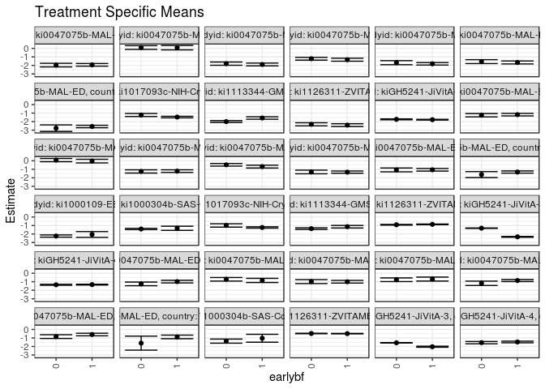

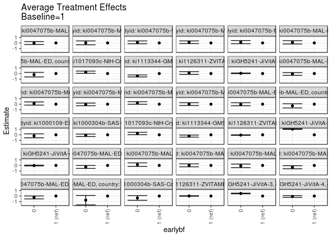

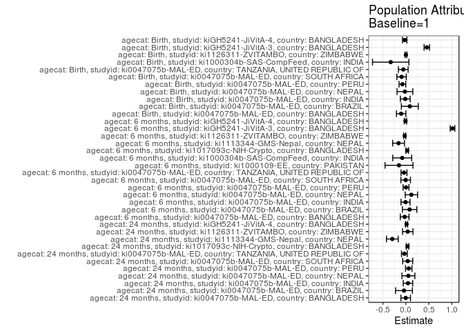

## Results Table

### Parameter: TSM

| agecat | studyid | country | intervention_level | baseline_level | estimate | ci_lower | ci_upper |
| --- | --- | --- | --- | --- | --- | --- | --- |
| Birth | ki0047075b-MAL-ED | BANGLADESH | 1 | NA | -0.9852084 | -1.1392575 | -0.8311593 |
| Birth | ki0047075b-MAL-ED | BANGLADESH | 0 | NA | -1.2555623 | -1.4711419 | -1.0399826 |
| Birth | ki0047075b-MAL-ED | BRAZIL | 1 | NA | -0.8474140 | -1.0922082 | -0.6026197 |
| Birth | ki0047075b-MAL-ED | BRAZIL | 0 | NA | -0.7122774 | -0.9212885 | -0.5032664 |
| Birth | ki0047075b-MAL-ED | INDIA | 1 | NA | -1.0008214 | -1.1596069 | -0.8420358 |
| Birth | ki0047075b-MAL-ED | INDIA | 0 | NA | -0.9821734 | -1.2147098 | -0.7496369 |
| Birth | ki0047075b-MAL-ED | NEPAL | 1 | NA | -0.6884833 | -0.9199045 | -0.4570621 |
| Birth | ki0047075b-MAL-ED | NEPAL | 0 | NA | -0.7666207 | -0.9815265 | -0.5517148 |
| Birth | ki0047075b-MAL-ED | PERU | 1 | NA | -0.8567305 | -0.9773190 | -0.7361420 |
| Birth | ki0047075b-MAL-ED | PERU | 0 | NA | -1.1815662 | -1.4350646 | -0.9280677 |
| Birth | ki0047075b-MAL-ED | SOUTH AFRICA | 1 | NA | -0.5973458 | -0.7497390 | -0.4449526 |
| Birth | ki0047075b-MAL-ED | SOUTH AFRICA | 0 | NA | -0.8401198 | -1.0593161 | -0.6209235 |
| Birth | ki0047075b-MAL-ED | TANZANIA, UNITED REPUBLIC OF | 1 | NA | -0.8777653 | -1.0892003 | -0.6663303 |
| Birth | ki0047075b-MAL-ED | TANZANIA, UNITED REPUBLIC OF | 0 | NA | -1.6093658 | -2.4299311 | -0.7888005 |
| Birth | ki1000304b-SAS-CompFeed | INDIA | 1 | NA | -1.0362763 | -1.5020057 | -0.5705468 |
| Birth | ki1000304b-SAS-CompFeed | INDIA | 0 | NA | -1.3736924 | -1.6131985 | -1.1341863 |
| Birth | ki1126311-ZVITAMBO | ZIMBABWE | 1 | NA | -0.4915467 | -0.5217826 | -0.4613109 |
| Birth | ki1126311-ZVITAMBO | ZIMBABWE | 0 | NA | -0.4759705 | -0.5074515 | -0.4444894 |
| Birth | kiGH5241-JiVitA-3 | BANGLADESH | 1 | NA | -2.0316720 | -2.0913447 | -1.9719994 |
| Birth | kiGH5241-JiVitA-3 | BANGLADESH | 0 | NA | -1.5726467 | -1.5927592 | -1.5525343 |
| Birth | kiGH5241-JiVitA-4 | BANGLADESH | 1 | NA | -1.4729315 | -1.5690307 | -1.3768323 |
| Birth | kiGH5241-JiVitA-4 | BANGLADESH | 0 | NA | -1.5519678 | -1.6892019 | -1.4147338 |
| 6 months | ki0047075b-MAL-ED | BANGLADESH | 1 | NA | -1.1802598 | -1.3304137 | -1.0301058 |
| 6 months | ki0047075b-MAL-ED | BANGLADESH | 0 | NA | -1.2498031 | -1.4460854 | -1.0535208 |
| 6 months | ki0047075b-MAL-ED | BRAZIL | 1 | NA | -0.0312487 | -0.2476545 | 0.1851571 |
| 6 months | ki0047075b-MAL-ED | BRAZIL | 0 | NA | 0.0835331 | -0.1048348 | 0.2719011 |
| 6 months | ki0047075b-MAL-ED | INDIA | 1 | NA | -1.2123888 | -1.3650277 | -1.0597499 |
| 6 months | ki0047075b-MAL-ED | INDIA | 0 | NA | -1.2495371 | -1.4388327 | -1.0602414 |
| 6 months | ki0047075b-MAL-ED | NEPAL | 1 | NA | -0.6816035 | -0.8482043 | -0.5150026 |
| 6 months | ki0047075b-MAL-ED | NEPAL | 0 | NA | -0.4715500 | -0.6236225 | -0.3194775 |
| 6 months | ki0047075b-MAL-ED | PERU | 1 | NA | -1.3305150 | -1.4587229 | -1.2023072 |
| 6 months | ki0047075b-MAL-ED | PERU | 0 | NA | -1.3131220 | -1.5266103 | -1.0996338 |
| 6 months | ki0047075b-MAL-ED | SOUTH AFRICA | 1 | NA | -1.0560711 | -1.2106075 | -0.9015346 |
| 6 months | ki0047075b-MAL-ED | SOUTH AFRICA | 0 | NA | -1.0706196 | -1.2974113 | -0.8438278 |
| 6 months | ki0047075b-MAL-ED | TANZANIA, UNITED REPUBLIC OF | 1 | NA | -1.3198921 | -1.4472244 | -1.1925599 |
| 6 months | ki0047075b-MAL-ED | TANZANIA, UNITED REPUBLIC OF | 0 | NA | -1.6209896 | -1.9727058 | -1.2692735 |
| 6 months | ki1000109-EE | PAKISTAN | 1 | NA | -2.0513719 | -2.3905931 | -1.7121506 |
| 6 months | ki1000109-EE | PAKISTAN | 0 | NA | -2.2357632 | -2.3666301 | -2.1048963 |
| 6 months | ki1000304b-SAS-CompFeed | INDIA | 1 | NA | -1.3228755 | -1.5653814 | -1.0803695 |
| 6 months | ki1000304b-SAS-CompFeed | INDIA | 0 | NA | -1.4080595 | -1.4833248 | -1.3327941 |
| 6 months | ki1017093c-NIH-Crypto | BANGLADESH | 1 | NA | -1.2280087 | -1.3045788 | -1.1514386 |
| 6 months | ki1017093c-NIH-Crypto | BANGLADESH | 0 | NA | -0.9913216 | -1.1901881 | -0.7924551 |
| 6 months | ki1113344-GMS-Nepal | NEPAL | 1 | NA | -1.1399927 | -1.2910732 | -0.9889123 |
| 6 months | ki1113344-GMS-Nepal | NEPAL | 0 | NA | -1.3661356 | -1.4637586 | -1.2685126 |
| 6 months | ki1126311-ZVITAMBO | ZIMBABWE | 1 | NA | -0.8606442 | -0.8968586 | -0.8244298 |
| 6 months | ki1126311-ZVITAMBO | ZIMBABWE | 0 | NA | -0.9112890 | -0.9501080 | -0.8724700 |
| 6 months | kiGH5241-JiVitA-3 | BANGLADESH | 1 | NA | -2.3293063 | -2.3755976 | -2.2830150 |
| 6 months | kiGH5241-JiVitA-3 | BANGLADESH | 0 | NA | -1.3109490 | -1.3345960 | -1.2873021 |
| 6 months | kiGH5241-JiVitA-4 | BANGLADESH | 1 | NA | -1.3363027 | -1.3822645 | -1.2903409 |
| 6 months | kiGH5241-JiVitA-4 | BANGLADESH | 0 | NA | -1.3586890 | -1.4175199 | -1.2998582 |
| 24 months | ki0047075b-MAL-ED | BANGLADESH | 1 | NA | -1.9351213 | -2.0906277 | -1.7796149 |
| 24 months | ki0047075b-MAL-ED | BANGLADESH | 0 | NA | -1.9627460 | -2.1753683 | -1.7501238 |
| 24 months | ki0047075b-MAL-ED | BRAZIL | 1 | NA | 0.0826262 | -0.1746390 | 0.3398914 |
| 24 months | ki0047075b-MAL-ED | BRAZIL | 0 | NA | 0.0998169 | -0.1192413 | 0.3188750 |
| 24 months | ki0047075b-MAL-ED | INDIA | 1 | NA | -1.8924186 | -2.0586934 | -1.7261438 |
| 24 months | ki0047075b-MAL-ED | INDIA | 0 | NA | -1.7915984 | -1.9803439 | -1.6028529 |
| 24 months | ki0047075b-MAL-ED | NEPAL | 1 | NA | -1.3304488 | -1.5066019 | -1.1542957 |
| 24 months | ki0047075b-MAL-ED | NEPAL | 0 | NA | -1.2160488 | -1.3799276 | -1.0521700 |
| 24 months | ki0047075b-MAL-ED | PERU | 1 | NA | -1.8132446 | -1.9546259 | -1.6718633 |
| 24 months | ki0047075b-MAL-ED | PERU | 0 | NA | -1.6791114 | -1.9153812 | -1.4428416 |
| 24 months | ki0047075b-MAL-ED | SOUTH AFRICA | 1 | NA | -1.6552938 | -1.8306631 | -1.4799245 |
| 24 months | ki0047075b-MAL-ED | SOUTH AFRICA | 0 | NA | -1.5536449 | -1.7822483 | -1.3250416 |
| 24 months | ki0047075b-MAL-ED | TANZANIA, UNITED REPUBLIC OF | 1 | NA | -2.5738071 | -2.7182732 | -2.4293409 |
| 24 months | ki0047075b-MAL-ED | TANZANIA, UNITED REPUBLIC OF | 0 | NA | -2.7695260 | -3.1556251 | -2.3834269 |
| 24 months | ki1017093c-NIH-Crypto | BANGLADESH | 1 | NA | -1.4657865 | -1.5575998 | -1.3739733 |
| 24 months | ki1017093c-NIH-Crypto | BANGLADESH | 0 | NA | -1.2243032 | -1.4015356 | -1.0470708 |
| 24 months | ki1113344-GMS-Nepal | NEPAL | 1 | NA | -1.5750668 | -1.7186068 | -1.4315268 |
| 24 months | ki1113344-GMS-Nepal | NEPAL | 0 | NA | -1.9970995 | -2.1069356 | -1.8872635 |
| 24 months | ki1126311-ZVITAMBO | ZIMBABWE | 1 | NA | -2.4130405 | -2.5782373 | -2.2478436 |
| 24 months | ki1126311-ZVITAMBO | ZIMBABWE | 0 | NA | -2.3194257 | -2.5005802 | -2.1382712 |
| 24 months | kiGH5241-JiVitA-4 | BANGLADESH | 1 | NA | -1.7737631 | -1.8178828 | -1.7296434 |
| 24 months | kiGH5241-JiVitA-4 | BANGLADESH | 0 | NA | -1.7319210 | -1.7847340 | -1.6791080 |

### Parameter: E(Y)

| agecat | studyid | country | intervention_level | baseline_level | estimate | ci_lower | ci_upper |
| --- | --- | --- | --- | --- | --- | --- | --- |
| Birth | ki0047075b-MAL-ED | BANGLADESH | NA | NA | -1.0876172 | -1.2136298 | -0.9616045 |
| Birth | ki0047075b-MAL-ED | BRAZIL | NA | NA | -0.7609424 | -0.9178311 | -0.6040538 |
| Birth | ki0047075b-MAL-ED | INDIA | NA | NA | -1.0138537 | -1.1537563 | -0.8739510 |
| Birth | ki0047075b-MAL-ED | NEPAL | NA | NA | -0.7089017 | -0.8656064 | -0.5521971 |
| Birth | ki0047075b-MAL-ED | PERU | NA | NA | -0.9322300 | -1.0461262 | -0.8183337 |
| Birth | ki0047075b-MAL-ED | SOUTH AFRICA | NA | NA | -0.6902024 | -0.8168430 | -0.5635618 |
| Birth | ki0047075b-MAL-ED | TANZANIA, UNITED REPUBLIC OF | NA | NA | -0.9338211 | -1.1465079 | -0.7211344 |
| Birth | ki1000304b-SAS-CompFeed | INDIA | NA | NA | -1.3661582 | -1.6025814 | -1.1297350 |
| Birth | ki1126311-ZVITAMBO | ZIMBABWE | NA | NA | -0.4898628 | -0.5117273 | -0.4679983 |
| Birth | kiGH5241-JiVitA-3 | BANGLADESH | NA | NA | -1.5752894 | -1.5950861 | -1.5554927 |
| Birth | kiGH5241-JiVitA-4 | BANGLADESH | NA | NA | -1.4976642 | -1.5817349 | -1.4135935 |
| 6 months | ki0047075b-MAL-ED | BANGLADESH | NA | NA | -1.2063264 | -1.3242819 | -1.0883709 |
| 6 months | ki0047075b-MAL-ED | BRAZIL | NA | NA | 0.0510207 | -0.0930194 | 0.1950608 |
| 6 months | ki0047075b-MAL-ED | INDIA | NA | NA | -1.2203672 | -1.3387619 | -1.1019726 |
| 6 months | ki0047075b-MAL-ED | NEPAL | NA | NA | -0.5610593 | -0.6737915 | -0.4483272 |
| 6 months | ki0047075b-MAL-ED | PERU | NA | NA | -1.3268010 | -1.4351217 | -1.2184802 |
| 6 months | ki0047075b-MAL-ED | SOUTH AFRICA | NA | NA | -1.0599367 | -1.1887637 | -0.9311096 |
| 6 months | ki0047075b-MAL-ED | TANZANIA, UNITED REPUBLIC OF | NA | NA | -1.3601215 | -1.4821830 | -1.2380600 |
| 6 months | ki1000109-EE | PAKISTAN | NA | NA | -2.2004704 | -2.3234073 | -2.0775336 |
| 6 months | ki1000304b-SAS-CompFeed | INDIA | NA | NA | -1.4018563 | -1.4810585 | -1.3226541 |
| 6 months | ki1017093c-NIH-Crypto | BANGLADESH | NA | NA | -1.1986783 | -1.2700937 | -1.1272630 |
| 6 months | ki1113344-GMS-Nepal | NEPAL | NA | NA | -1.2991993 | -1.3810668 | -1.2173319 |
| 6 months | ki1126311-ZVITAMBO | ZIMBABWE | NA | NA | -0.8848717 | -0.9125215 | -0.8572218 |
| 6 months | kiGH5241-JiVitA-3 | BANGLADESH | NA | NA | -1.3130932 | -1.3362359 | -1.2899505 |
| 6 months | kiGH5241-JiVitA-4 | BANGLADESH | NA | NA | -1.3447940 | -1.3820261 | -1.3075620 |
| 24 months | ki0047075b-MAL-ED | BANGLADESH | NA | NA | -1.9381280 | -2.0644004 | -1.8118555 |
| 24 months | ki0047075b-MAL-ED | BRAZIL | NA | NA | 0.0418343 | -0.1253834 | 0.2090521 |
| 24 months | ki0047075b-MAL-ED | INDIA | NA | NA | -1.8458150 | -1.9718703 | -1.7197596 |
| 24 months | ki0047075b-MAL-ED | NEPAL | NA | NA | -1.2752193 | -1.3954783 | -1.1549603 |
| 24 months | ki0047075b-MAL-ED | PERU | NA | NA | -1.7500995 | -1.8705474 | -1.6296516 |
| 24 months | ki0047075b-MAL-ED | SOUTH AFRICA | NA | NA | -1.6144681 | -1.7508611 | -1.4780751 |
| 24 months | ki0047075b-MAL-ED | TANZANIA, UNITED REPUBLIC OF | NA | NA | -2.6058879 | -2.7403043 | -2.4714714 |
| 24 months | ki1017093c-NIH-Crypto | BANGLADESH | NA | NA | -1.4295331 | -1.5127726 | -1.3462935 |
| 24 months | ki1113344-GMS-Nepal | NEPAL | NA | NA | -1.8698242 | -1.9591140 | -1.7805343 |
| 24 months | ki1126311-ZVITAMBO | ZIMBABWE | NA | NA | -2.3716792 | -2.4955680 | -2.2477904 |
| 24 months | kiGH5241-JiVitA-4 | BANGLADESH | NA | NA | -1.7582681 | -1.7937283 | -1.7228079 |

### Parameter: ATE

| agecat | studyid | country | intervention_level | baseline_level | estimate | ci_lower | ci_upper |
| --- | --- | --- | --- | --- | --- | --- | --- |
| Birth | ki0047075b-MAL-ED | BANGLADESH | 1 | 1 | 0.0000000 | 0.0000000 | 0.0000000 |
| Birth | ki0047075b-MAL-ED | BANGLADESH | 0 | 1 | -0.2703538 | -0.5362028 | -0.0045049 |
| Birth | ki0047075b-MAL-ED | BRAZIL | 1 | 1 | 0.0000000 | 0.0000000 | 0.0000000 |
| Birth | ki0047075b-MAL-ED | BRAZIL | 0 | 1 | 0.1351365 | -0.1873867 | 0.4576597 |
| Birth | ki0047075b-MAL-ED | INDIA | 1 | 1 | 0.0000000 | 0.0000000 | 0.0000000 |
| Birth | ki0047075b-MAL-ED | INDIA | 0 | 1 | 0.0186480 | -0.2467998 | 0.2840958 |
| Birth | ki0047075b-MAL-ED | NEPAL | 1 | 1 | 0.0000000 | 0.0000000 | 0.0000000 |
| Birth | ki0047075b-MAL-ED | NEPAL | 0 | 1 | -0.0781374 | -0.3960430 | 0.2397682 |
| Birth | ki0047075b-MAL-ED | PERU | 1 | 1 | 0.0000000 | 0.0000000 | 0.0000000 |
| Birth | ki0047075b-MAL-ED | PERU | 0 | 1 | -0.3248357 | -0.6014710 | -0.0482003 |
| Birth | ki0047075b-MAL-ED | SOUTH AFRICA | 1 | 1 | 0.0000000 | 0.0000000 | 0.0000000 |
| Birth | ki0047075b-MAL-ED | SOUTH AFRICA | 0 | 1 | -0.2427740 | -0.5077944 | 0.0222465 |
| Birth | ki0047075b-MAL-ED | TANZANIA, UNITED REPUBLIC OF | 1 | 1 | 0.0000000 | 0.0000000 | 0.0000000 |
| Birth | ki0047075b-MAL-ED | TANZANIA, UNITED REPUBLIC OF | 0 | 1 | -0.7316005 | -1.5789483 | 0.1157472 |
| Birth | ki1000304b-SAS-CompFeed | INDIA | 1 | 1 | 0.0000000 | 0.0000000 | 0.0000000 |
| Birth | ki1000304b-SAS-CompFeed | INDIA | 0 | 1 | -0.3374161 | -0.7525667 | 0.0777345 |
| Birth | ki1126311-ZVITAMBO | ZIMBABWE | 1 | 1 | 0.0000000 | 0.0000000 | 0.0000000 |
| Birth | ki1126311-ZVITAMBO | ZIMBABWE | 0 | 1 | 0.0155763 | -0.0266691 | 0.0578216 |
| Birth | kiGH5241-JiVitA-3 | BANGLADESH | 1 | 1 | 0.0000000 | 0.0000000 | 0.0000000 |
| Birth | kiGH5241-JiVitA-3 | BANGLADESH | 0 | 1 | 0.4590253 | 0.3980059 | 0.5200447 |
| Birth | kiGH5241-JiVitA-4 | BANGLADESH | 1 | 1 | 0.0000000 | 0.0000000 | 0.0000000 |
| Birth | kiGH5241-JiVitA-4 | BANGLADESH | 0 | 1 | -0.0790363 | -0.2331900 | 0.0751173 |
| 6 months | ki0047075b-MAL-ED | BANGLADESH | 1 | 1 | 0.0000000 | 0.0000000 | 0.0000000 |
| 6 months | ki0047075b-MAL-ED | BANGLADESH | 0 | 1 | -0.0695433 | -0.3174653 | 0.1783786 |
| 6 months | ki0047075b-MAL-ED | BRAZIL | 1 | 1 | 0.0000000 | 0.0000000 | 0.0000000 |
| 6 months | ki0047075b-MAL-ED | BRAZIL | 0 | 1 | 0.1147818 | -0.1696267 | 0.3991904 |
| 6 months | ki0047075b-MAL-ED | INDIA | 1 | 1 | 0.0000000 | 0.0000000 | 0.0000000 |
| 6 months | ki0047075b-MAL-ED | INDIA | 0 | 1 | -0.0371483 | -0.2797864 | 0.2054898 |
| 6 months | ki0047075b-MAL-ED | NEPAL | 1 | 1 | 0.0000000 | 0.0000000 | 0.0000000 |
| 6 months | ki0047075b-MAL-ED | NEPAL | 0 | 1 | 0.2100535 | -0.0156819 | 0.4357889 |
| 6 months | ki0047075b-MAL-ED | PERU | 1 | 1 | 0.0000000 | 0.0000000 | 0.0000000 |
| 6 months | ki0047075b-MAL-ED | PERU | 0 | 1 | 0.0173930 | -0.2322073 | 0.2669933 |
| 6 months | ki0047075b-MAL-ED | SOUTH AFRICA | 1 | 1 | 0.0000000 | 0.0000000 | 0.0000000 |
| 6 months | ki0047075b-MAL-ED | SOUTH AFRICA | 0 | 1 | -0.0145485 | -0.2891428 | 0.2600458 |
| 6 months | ki0047075b-MAL-ED | TANZANIA, UNITED REPUBLIC OF | 1 | 1 | 0.0000000 | 0.0000000 | 0.0000000 |
| 6 months | ki0047075b-MAL-ED | TANZANIA, UNITED REPUBLIC OF | 0 | 1 | -0.3010975 | -0.6748751 | 0.0726801 |
| 6 months | ki1000109-EE | PAKISTAN | 1 | 1 | 0.0000000 | 0.0000000 | 0.0000000 |
| 6 months | ki1000109-EE | PAKISTAN | 0 | 1 | -0.1843913 | -0.5456749 | 0.1768922 |
| 6 months | ki1000304b-SAS-CompFeed | INDIA | 1 | 1 | 0.0000000 | 0.0000000 | 0.0000000 |
| 6 months | ki1000304b-SAS-CompFeed | INDIA | 0 | 1 | -0.0851840 | -0.3052916 | 0.1349236 |
| 6 months | ki1017093c-NIH-Crypto | BANGLADESH | 1 | 1 | 0.0000000 | 0.0000000 | 0.0000000 |
| 6 months | ki1017093c-NIH-Crypto | BANGLADESH | 0 | 1 | 0.2366871 | 0.0234877 | 0.4498865 |
| 6 months | ki1113344-GMS-Nepal | NEPAL | 1 | 1 | 0.0000000 | 0.0000000 | 0.0000000 |
| 6 months | ki1113344-GMS-Nepal | NEPAL | 0 | 1 | -0.2261429 | -0.4062308 | -0.0460549 |
| 6 months | ki1126311-ZVITAMBO | ZIMBABWE | 1 | 1 | 0.0000000 | 0.0000000 | 0.0000000 |
| 6 months | ki1126311-ZVITAMBO | ZIMBABWE | 0 | 1 | -0.0506448 | -0.1008734 | -0.0004163 |
| 6 months | kiGH5241-JiVitA-3 | BANGLADESH | 1 | 1 | 0.0000000 | 0.0000000 | 0.0000000 |
| 6 months | kiGH5241-JiVitA-3 | BANGLADESH | 0 | 1 | 1.0183573 | 0.9663852 | 1.0703293 |
| 6 months | kiGH5241-JiVitA-4 | BANGLADESH | 1 | 1 | 0.0000000 | 0.0000000 | 0.0000000 |
| 6 months | kiGH5241-JiVitA-4 | BANGLADESH | 0 | 1 | -0.0223863 | -0.0946804 | 0.0499077 |
| 24 months | ki0047075b-MAL-ED | BANGLADESH | 1 | 1 | 0.0000000 | 0.0000000 | 0.0000000 |
| 24 months | ki0047075b-MAL-ED | BANGLADESH | 0 | 1 | -0.0276247 | -0.2899853 | 0.2347358 |
| 24 months | ki0047075b-MAL-ED | BRAZIL | 1 | 1 | 0.0000000 | 0.0000000 | 0.0000000 |
| 24 months | ki0047075b-MAL-ED | BRAZIL | 0 | 1 | 0.0171907 | -0.3230428 | 0.3574241 |
| 24 months | ki0047075b-MAL-ED | INDIA | 1 | 1 | 0.0000000 | 0.0000000 | 0.0000000 |
| 24 months | ki0047075b-MAL-ED | INDIA | 0 | 1 | 0.1008202 | -0.1490776 | 0.3507180 |
| 24 months | ki0047075b-MAL-ED | NEPAL | 1 | 1 | 0.0000000 | 0.0000000 | 0.0000000 |
| 24 months | ki0047075b-MAL-ED | NEPAL | 0 | 1 | 0.1144000 | -0.1272593 | 0.3560593 |
| 24 months | ki0047075b-MAL-ED | PERU | 1 | 1 | 0.0000000 | 0.0000000 | 0.0000000 |
| 24 months | ki0047075b-MAL-ED | PERU | 0 | 1 | 0.1341332 | -0.1424798 | 0.4107462 |
| 24 months | ki0047075b-MAL-ED | SOUTH AFRICA | 1 | 1 | 0.0000000 | 0.0000000 | 0.0000000 |
| 24 months | ki0047075b-MAL-ED | SOUTH AFRICA | 0 | 1 | 0.1016489 | -0.1870810 | 0.3903788 |
| 24 months | ki0047075b-MAL-ED | TANZANIA, UNITED REPUBLIC OF | 1 | 1 | 0.0000000 | 0.0000000 | 0.0000000 |
| 24 months | ki0047075b-MAL-ED | TANZANIA, UNITED REPUBLIC OF | 0 | 1 | -0.1957190 | -0.6083782 | 0.2169402 |
| 24 months | ki1017093c-NIH-Crypto | BANGLADESH | 1 | 1 | 0.0000000 | 0.0000000 | 0.0000000 |
| 24 months | ki1017093c-NIH-Crypto | BANGLADESH | 0 | 1 | 0.2414834 | 0.0420497 | 0.4409171 |
| 24 months | ki1113344-GMS-Nepal | NEPAL | 1 | 1 | 0.0000000 | 0.0000000 | 0.0000000 |
| 24 months | ki1113344-GMS-Nepal | NEPAL | 0 | 1 | -0.4220328 | -0.6028995 | -0.2411661 |
| 24 months | ki1126311-ZVITAMBO | ZIMBABWE | 1 | 1 | 0.0000000 | 0.0000000 | 0.0000000 |
| 24 months | ki1126311-ZVITAMBO | ZIMBABWE | 0 | 1 | 0.0936148 | -0.1489551 | 0.3361846 |
| 24 months | kiGH5241-JiVitA-4 | BANGLADESH | 1 | 1 | 0.0000000 | 0.0000000 | 0.0000000 |
| 24 months | kiGH5241-JiVitA-4 | BANGLADESH | 0 | 1 | 0.0418421 | -0.0231420 | 0.1068262 |

### Parameter: PAR

| agecat | studyid | country | intervention_level | baseline_level | estimate | ci_lower | ci_upper |
| --- | --- | --- | --- | --- | --- | --- | --- |
| Birth | ki0047075b-MAL-ED | BANGLADESH | 1 | NA | -0.1024087 | -0.2051522 | 0.0003347 |
| Birth | ki0047075b-MAL-ED | BRAZIL | 1 | NA | 0.0864715 | -0.0979857 | 0.2709288 |
| Birth | ki0047075b-MAL-ED | INDIA | 1 | NA | -0.0130323 | -0.1194508 | 0.0933863 |
| Birth | ki0047075b-MAL-ED | NEPAL | 1 | NA | -0.0204184 | -0.1926704 | 0.1518335 |
| Birth | ki0047075b-MAL-ED | PERU | 1 | NA | -0.0754995 | -0.1483433 | -0.0026557 |
| Birth | ki0047075b-MAL-ED | SOUTH AFRICA | 1 | NA | -0.0928566 | -0.1956573 | 0.0099441 |
| Birth | ki0047075b-MAL-ED | TANZANIA, UNITED REPUBLIC OF | 1 | NA | -0.0560559 | -0.1618975 | 0.0497858 |
| Birth | ki1000304b-SAS-CompFeed | INDIA | 1 | NA | -0.3298819 | -0.7262593 | 0.0664955 |
| Birth | ki1126311-ZVITAMBO | ZIMBABWE | 1 | NA | 0.0016839 | -0.0199570 | 0.0233248 |
| Birth | kiGH5241-JiVitA-3 | BANGLADESH | 1 | NA | 0.4563827 | 0.3972208 | 0.5155445 |
| Birth | kiGH5241-JiVitA-4 | BANGLADESH | 1 | NA | -0.0247327 | -0.0727556 | 0.0232901 |
| 6 months | ki0047075b-MAL-ED | BANGLADESH | 1 | NA | -0.0260666 | -0.1210376 | 0.0689043 |
| 6 months | ki0047075b-MAL-ED | BRAZIL | 1 | NA | 0.0822694 | -0.0737850 | 0.2383238 |
| 6 months | ki0047075b-MAL-ED | INDIA | 1 | NA | -0.0079784 | -0.1057787 | 0.0898219 |
| 6 months | ki0047075b-MAL-ED | NEPAL | 1 | NA | 0.1205441 | -0.0144016 | 0.2554899 |
| 6 months | ki0047075b-MAL-ED | PERU | 1 | NA | 0.0037141 | -0.0602204 | 0.0676485 |
| 6 months | ki0047075b-MAL-ED | SOUTH AFRICA | 1 | NA | -0.0038656 | -0.1086159 | 0.1008847 |
| 6 months | ki0047075b-MAL-ED | TANZANIA, UNITED REPUBLIC OF | 1 | NA | -0.0402293 | -0.1047644 | 0.0243057 |
| 6 months | ki1000109-EE | PAKISTAN | 1 | NA | -0.1490986 | -0.4534895 | 0.1552923 |
| 6 months | ki1000304b-SAS-CompFeed | INDIA | 1 | NA | -0.0789808 | -0.2850706 | 0.1271089 |
| 6 months | ki1017093c-NIH-Crypto | BANGLADESH | 1 | NA | 0.0293304 | 0.0005663 | 0.0580944 |
| 6 months | ki1113344-GMS-Nepal | NEPAL | 1 | NA | -0.1592066 | -0.2866894 | -0.0317238 |
| 6 months | ki1126311-ZVITAMBO | ZIMBABWE | 1 | NA | -0.0242275 | -0.0476982 | -0.0007568 |
| 6 months | kiGH5241-JiVitA-3 | BANGLADESH | 1 | NA | 1.0162131 | 0.9655023 | 1.0669238 |
| 6 months | kiGH5241-JiVitA-4 | BANGLADESH | 1 | NA | -0.0084913 | -0.0346170 | 0.0176343 |
| 24 months | ki0047075b-MAL-ED | BANGLADESH | 1 | NA | -0.0030067 | -0.1073262 | 0.1013128 |
| 24 months | ki0047075b-MAL-ED | BRAZIL | 1 | NA | -0.0407919 | -0.2246254 | 0.1430416 |
| 24 months | ki0047075b-MAL-ED | INDIA | 1 | NA | 0.0466036 | -0.0560872 | 0.1492945 |
| 24 months | ki0047075b-MAL-ED | NEPAL | 1 | NA | 0.0552295 | -0.0859234 | 0.1963824 |
| 24 months | ki0047075b-MAL-ED | PERU | 1 | NA | 0.0631451 | -0.0066598 | 0.1329500 |
| 24 months | ki0047075b-MAL-ED | SOUTH AFRICA | 1 | NA | 0.0408258 | -0.0678161 | 0.1494676 |
| 24 months | ki0047075b-MAL-ED | TANZANIA, UNITED REPUBLIC OF | 1 | NA | -0.0320808 | -0.0951602 | 0.0309986 |
| 24 months | ki1017093c-NIH-Crypto | BANGLADESH | 1 | NA | 0.0362535 | 0.0078278 | 0.0646791 |
| 24 months | ki1113344-GMS-Nepal | NEPAL | 1 | NA | -0.2947574 | -0.4227692 | -0.1667455 |
| 24 months | ki1126311-ZVITAMBO | ZIMBABWE | 1 | NA | 0.0413613 | -0.0720228 | 0.1547453 |
| 24 months | kiGH5241-JiVitA-4 | BANGLADESH | 1 | NA | 0.0154950 | -0.0078824 | 0.0388724 |